# How We Use AI Matters

Ethics, governance, and safe use at the World Bank Group

Maria Reyes Retana

DECDI, The World Bank

2026-09-29

## Have you ever…?

0

0

0

0

0

0

## You’re Not the Only One

Whatever you raised your hand for, you weren’t the only one. That’s not a coincidence — the rules for AI are new, unevenly known, and nobody’s really taught them yet. This hour is that teaching.

# 1 · Why It Matters

## The question for today

AI can produce useful work quickly. Nobody in this room needs convincing of that.

What must we do to ensure that the work is also accurate, fair, secure, and defensible?

By the end, you should be able to:

- name AI risks and what to do about each
- choose the right tool for the type of data
- see where each risk shows up in our work, and think of who is harmed if it goes wrong

## Why this matters (for our work and beyond)

**AI is already in the workflow**Drafting, coding, summarising, translating, analysing. At work and at home. The question is no longer whether we use it, but whether we use it well.

**Our errors travel**Research feeds policy advice, lending, and targeting.

**Our data is about people**Access to a dataset does not authorise every new use of it. Prompts, uploads, and chat histories are data too — at the Bank, and on your phone.

**The harm is not evenly spread**When AI is wrong, it is usually wrong about the people already least visible in the data. Mostly, the people we exist to serve.

# 2 · What the Bank Asks

## Where the guidance comes from

There are a lot of frameworks: OECD, UNESCO, NIST, ISO, the EU AI Act, and more. It is hard to know which one applies to our work; but for WBG work, one of them governs, and they mostly agree on what matters.

**They agree on**Accountability · fairness · validity and security · privacy and transparency · watching for harm.

**They differ on**Definitions, thresholds, remedies; and which of them actually binds you.

The hard part is not disagreement about what matters. It is knowing which document to follow for the task in front of you. **For WBG work, the Bank’s framework governs**; the five risks on the next slide.

**For reference, not for today:** [OECD](https://oecd.ai/en/ai-principles) · [UNESCO](https://www.unesco.org/en/artificial-intelligence/recommendation-ethics) · [NIST AI RMF](https://airc.nist.gov/) · [ISO/IEC 42001](https://www.iso.org/artificial-intelligence/responsible-ai-ethics) · [EU AI Act](https://eur-lex.europa.eu/eli/reg/2024/1689/oj)

## Five risks to consider when you use AI

The WBG AI Risk Management Framework groups what can go wrong when you use AI into **five risks**. Click each one to see what it means and how it shows up in research work.

WBG AI  
Risk  
Framework

**Source:** [WBG AI Risk Management Framework](https://worldbankgroup.sharepoint.com/:p:/s/ITSSRFiles/EYRhCk4Xdh1PkVpeB1uw9egBWBIV5tJcBlTMQRFW1HbtOQ?e=6xh3wK&CID=BB4D28B7-094F-4C2F-ADF5-1B27D4E72EAE&wdLOR=cF67CCC10-3A55-4C8C-BE42-210E53B70B08).

## What you may never do

Most AI use involves judgment calls. These six don’t: the Bank prohibits them.

**Never use AI to:**

- Cause or worsen harm to people or communities, whether social, cultural, economic, environmental or political.
- Promote bias, discrimination or stigma against individuals or groups.
- Make decisions that a person cannot override.
- Hide that AI was used.
- Manipulate or deceive.
- Infer someone’s emotions, such as a client’s or a counterpart’s.

The WBG prohibited practices, from the [Acceptable Use of AI Addendum](https://worldbankgroup.sharepoint.com/:p:/r/sites/AIWBG/Shared%20Documents/Guides/AI%20Prohibited%20Practices.pptx?d=w4073f635f0b04d7ca43dd588eddcbc73&csf=1&web=1&e=6JjC1W). They apply by any means, AI included. **From here on, blue boxes give practical checks; red boxes flag the prohibited practices described here.**

## What you should do!

Use the TACTIC Framework

|  | The check | Risk it addresses |
| --- | --- | --- |
| **T** Transparency | Have I disclosed meaningful AI assistance? | Legal |
| **A** Accountability | Have I verified the claims, and do I own this? | Validity · Accountability |
| **C** Context | Have I applied institutional, country, and cultural knowledge? | Validity · Ethical |
| **T** Take ownership | Is human judgment still in charge of the decision? | Accountability |
| **I** Impact | Who is wronged if this is wrong? | Ethical |
| **C** Compliance | Approved tool, right classification, data agreement respected? | Security & privacy · Legal |

**Source:** [T.A.C.T.I.C. AI Checklist from learning module (Using AI Responsibly@WBG](https://wbg.sabacloud.com/Saba/Web_spf/NA1PRD0002/app/me/learningeventdetail/cours000000000050989?classId=dowbt000000000017453)

# 3 · The Risks

## How the next part works

We take the five risks one at a time. Each slide follows the same pattern, so here is what to look for.

**A situation from research work.** Pick your answer before I click. Then we see which is best, and why the others fall short.

**Practical check**What to do in your own work.

**Blue: the practical check.** The habit to take away.

**Prohibited:** a Bank rule, not a judgment call.

**Red: a prohibited practice.** Shown only where one of the Bank's prohibited practices applies.

**Real case ·** what happened when it went wrong.

**A real case.** Documented, with a link, so you can read it yourself.

Some slides swap the scenario for a live example: my own tests with ChatGPT, Claude and Gemini, or a tool picker to click through.

## Accountability: who owns the decision?

A ministry of agriculture is about to launch an AI system that automatically approves or denies farmers’ fertilizer subsidy applications, based on land size, past harvests, and income. Accuracy testing, explaining the criteria to farmers, and independent certification are all worth doing — and the ministry has limited time before planting season starts. Which one condition would you insist on before anything else?

**C is correct.** All four matter — but only C protects the specific farmer the system gets wrong. Accuracy, transparency, and certification all describe the system in general; none of them do anything for an individual case once a mistake has already happened.  
If you can only insist on one thing before launch, insist on a way to catch and reverse individual errors. Everything else is worth doing, but this is the one thing that, if missing, means a wrongly denied farmer has nowhere to go.

**Practical check**

Verify and validate all output. You remain accountable for it.

**Prohibited**

Preventing humans from overriding AI-generated decisions.

**Real case · India:** since 2016, Telangana state has used a machine-learning system to merge records across government databases and catch duplicate or fraudulent welfare beneficiaries. Reporting found it has wrongly cut off thousands of families from food, income, and housing benefits due to database-merging errors. People affected are stuck in a bureaucratic maze with little to no way to contest it, and Amnesty International itself could not complete an audit of the system because of how opaque it is. ([Amnesty International, 2024](https://www.amnesty.org/en/latest/news/2024/04/india-global-new-technologies-in-automated-social-protection-systems-can-threaten-human-rights/))

## Validity: the confident wrong answer

**D was invented for this exercise.** Plausible journal, volume, article number, topic, authors. You cannot spot a fabricated citation by reading it, only by opening the original and checking that it says what you claim it says. The same goes for numbers, quotations, and for code: AI-written code that runs is not AI-written code that is correct.

**Practical check**

Review outputs for inaccuracy and incompleteness. AI is not an authoritative source.

“Verified” means you opened it and read it. Not that the tool said so, and not that the code ran without an error.

**Real case · New York, 2023:** lawyers filed a brief citing six court decisions that ChatGPT had invented, and vouched for them when the court asked. The court fined them $5,000. (*Mata v. Avianca*, No. 22-cv-1461, S.D.N.Y., [opinion on sanctions](https://www.courtlistener.com/docket/63107798/mata-v-avianca-inc/))

## Validity: similar fact, different sources

In September 2026 I asked three assistants for Mexico’s poverty rate, in **English** and in **Spanish**. (Two official sources for its measurement CONEVAL and INEGI)

ENGLISH

[figure not shown]

**5.3% extreme poverty, 2024.** Linked INEGI directly. But the retrieved set also held a WMO warmest-year bulletin, a sports highlights reel and a Dua Lipa concert clip.

ESPAÑOL

[figure not shown]

**29.6%, 38.5 millones, 2024.** Linked INEGI directly. Retrieved set: INEGI's press room, an INEGI post on X, and a Facebook post.

The only assistant that took me to the statistical agency — in both languages. I asked it two different questions here: *extreme* poverty in English, poverty in Spanish, and both answers are right for the question asked. What changed with the language was what it read to get there.

Every answer lands near the official figures (in this case). The numbers agree, so nothing looks wrong. Underneath: **not one linked CONEVAL**, **two never linked INEGI at all**, **only Gemini Enterprise** linked the World Bank and **what the model read changed with the language I asked in**.

**Practical check:** cite the measurement, never the assistant. If you cannot name the institution that produced the number and open the page it sits on, you do not have the number yet.

## Validity: when AI does the measuring

When AI turns responses or documents into research variables, it becomes part of the **measurement process**. Errors can differ across languages and groups and can change the findings. Check those errors against human-reviewed examples.

20,000 open-ended responses in French and Hausa. An LLM codes them in an hour and agrees with you on the ten you read. Hand-coding costs two weeks; the paper is due Friday. What is the least you need to make the AI codes usable?

**A is the best starting point.** A randomly selected, human-reviewed sample helps assess errors, including differences by language. The analysis must then account for those errors using an appropriate method.  
**B** misses confident mistakes. **C** treats an overall agreement score as sufficient, even when performance differs across groups. Neither establishes that the findings are reliable.

**Practical check**

Validate your claims. You own the estimate.

Choose the validation sample size for the task and relevant subgroups. Statistical corrections have assumptions and do not automatically guarantee reliable findings.

## Security: what you paste is what you leak

You want an approved WBG tool to draft the cleaning code for a Confidential household survey. The data is identified, so access is restricted to the people named in the IRB protocol — and separately, the data agreement says research use only. What do you give the tool?

**B is correct.** Writing cleaning code requires the shape of the data, not the records themselves, and a synthetic extract carries the structure and the quirks without carrying anybody.  
**D** confuses two separate permissions. Tool approval is not data authorisation — even a tool cleared for Confidential data doesn’t inherit the data agreement’s terms, and “research use only” governs regardless of which tool is used. Separately, the IRB approval under which this data was collected names the specific people allowed to access it, and an AI tool is not one of them. Either restriction alone would block this; here both apply.  
**C** sends Personal Data to someone outside the IRB’s approved list: twenty real rows carrying village, age, and household size identify households. This is a privacy/human-subjects violation, not a contract one — it would still be wrong even if the data agreement said nothing about research use.  
**A** gets the principle right but stops too early. The records should stay out, but the codebook and a synthetic extract contain no one, so the tool can still help. Refusing everything has a cost of its own: the code still gets written, by hand late at night or in a personal account.

**Practical check**

Clearance is not authorisation. Personal Data is separately governed by the [WBG Policy on Personal Data Privacy](https://worldbankgroup.sharepoint.com/sites/ppfonline/PPFDocuments/abbc6711-2d7e-409d-a1a5-07a703157d48.pdf.pdf), which requires a legitimate purpose for each use — and drafting cleaning code is not one. The assistant needs the shape of the data, not the people in it.

**Real case · Samsung, 2023:** Engineers pasted confidential semiconductor source code in to debug and optimise it, and another employee fed in an internal meeting recording to draft a summary. Unlike an ordinary leak, none of it could be pulled back: submitted data can be retained and used to improve the model. Samsung banned generative AI tools for staff within weeks. ([Forbes, 2 May 2023](https://www.forbes.com/sites/siladityaray/2023/05/02/samsung-bans-chatgpt-and-other-chatbots-for-employees-after-sensitive-code-leak/))

## Security: how restricted is your data?

Start with **the label on the information**, then choose the tool. Not the other way round.

| Classification | In our work | Which AI tools |
| --- | --- | --- |
| **Public** | Published reports, open data | Approved tools freely. Others only under the Addendum’s four conditions |
| **Official Use Only** | Most daily work | Approved WBG tools only |
| **Confidential** | Research microdata, HR, negotiation material | Approved WBG tools only, need to know |
| **Strictly Confidential** | Investigations, restricted Board or legal material | Ask ai@worldbankgroup.org first |

Switching off training in a personal account changes nothing about the label or the rules. And an approved tool does not answer whether the data agreement allows this use.

Four conditions: [Acceptable Use of AI Addendum](https://worldbankgroup.sharepoint.com/sites/ppfonline/PPFAnnex/727dee72-17dc-4648-a9d5-0252c01ff988Annex1.pdf). Classification: WBG Information Classification and Control Policy; label files with TagIt. Examples are illustrative. The label on the file governs.

Not on the approved list? Only under the four conditions of the [Acceptable Use of AI Addendum](https://worldbankgroup.sharepoint.com/sites/ppfonline/PPFAnnex/727dee72-17dc-4648-a9d5-0252c01ff988Annex1.pdf). **Sources:** AI@WBG · provider terms, accessed September 2026. Current approved tools: [ai.worldbankgroup.org](https://ai.worldbankgroup.org/).

## Ethical: where bias enters

A development agency wants to identify the poorest villages for a cash-transfer programme, but cannot survey every household in the country. It trains a model on satellite images — night-time lights, building density, roads — calibrated against the villages where survey data already exists, then uses it to estimate wealth in villages that were never surveyed. Before scaling this model nationwide, what needs to be true?

**C is correct.** The model is a proxy: it stands in for wealth using what’s visible from space. That’s only safe once you’ve tested whether the same visual markers mean the same thing everywhere it will be used — a dispersed pastoralist community won’t look like a poor village in the training data, it will look like nothing at all.  
**A** confirms the model fits where it was trained, not whether the same signal holds elsewhere. **B** fixes image availability, not whether the proxy is the right stand-in for welfare.

**Practical check**

Review output for unintended bias.

**Prohibited**

Using AI to promote bias, discrimination, or stigmatization; to manipulate or deceive; or to infer a person’s emotions.

**Real case · United States, 2019:** A health algorithm applied to about 200 million people a year needed a proxy for health need, so it was trained to predict healthcare *cost* instead. Because less is historically spent treating Black patients at the same level of illness, cost quietly measured *access* to care, not *need* for it — equally sick Black patients scored as healthier. Fixing it would have raised the share of Black patients flagged for extra care from 17.7% to 46.5%. ([Obermeyer et al. 2019](https://doi.org/10.1126/science.aax2342))

**Real case · Dermatology AI:** leading skin-cancer models were tested on a diverse set of clinical images, and accuracy dropped significantly. The models were better at finding cancer in lighter-skinned patients and underperformed for darker-skinned patients. ([Frasier et al. 2025](https://www.jdermis.com/full-text/the-blind-spots-of-artificial-intelligence-in-skin-cancer-diagnosis), reviewing Daneshjou et al. 2022)

## Ethical: four ways bias gets in

| Source | What it can mean for our work |
| --- | --- |
| **Training data** | Historical stereotypes and uneven representation influence responses. |
| **Model design** | Targets, labels and measures of success reward some outcomes over others. |
| **Inputs and retrieval** | Our documents, examples or selected sources omit relevant perspectives. |
| **Application** | We use the tool in a language or population where it has not been validated. |

Aggregate accuracy is compatible with total failure for the people we exist to serve. **Who is missing, and how could that change the result?**

## Legal: AI disclosure

Real case · *Journal of Applied Economics*, 2025

RETRACTION NOTICE

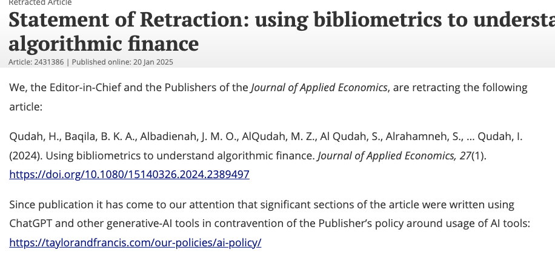

A paper published in August 2024 was **retracted in January 2025**. The editors found that significant sections had been written with ChatGPT and other generative AI tools, **contrary to the publisher's AI policy**.

**Read the policy before you submit.** Every journal sets its own AI rules. Break them and you can lose the paper.

At the Bank · the rule says *what*, not *how*

mAI ANSWER

[figure not shown]

The Acceptable Use of AI Addendum already requires it: *“Disclose the use of AI Output when used in World Bank Group’s external and internal facing websites, documents or publications.”* It **does not say how**. I asked mAI: it found **set labels only for CER** (External and Corporate Relations) and says the rollout report flags the missing format as a gap. Its source: the *Report on the WBG’s Rollout of the AI Governance Framework*, which **I am not allowed to open**.

**This is also a validity problem.** Even an approved tool can give me a claim I have no way to check. I can't verify it, so I can't cite it.

**Disclose it.** The Bank already requires disclosure, in internal and external documents alike. There is no set format yet, so say what you used and what you checked, as the next slide shows.

**Sources:** [WBG Acceptable Use of AI Addendum](https://worldbankgroup.sharepoint.com/sites/ppfonline/PPFAnnex/727dee72-17dc-4648-a9d5-0252c01ff988Annex1.pdf) · [Statement of retraction](https://doi.org/10.1080/15140326.2024.2431386), *Journal of Applied Economics* (2025) · [Taylor & Francis AI policy](https://taylorandfrancis.com/our-policies/ai-policy/) · mAI answer, author’s query, September 2026 (underlying report not accessible to the author).

# 4 · Where In The Work

## Compliance is the floor

Permission answers “may I use it?” Ethics asks “should I use it this way, and who carries the risk if it fails?”

A permitted use can still be misleading, exclusionary, poorly validated, or impossible to contest. Planning checks on AI risk early can prevent harm and expensive rework.

**So the last question is when in our work should we consider this?**

## The research lifecycle

**Design**What should AI support, and which judgments stay with us?

**Acquisition**Are we collecting or accessing data responsibly, and who is missing?

**Processing**Did the transformations preserve the meaning and integrity of the data?

**Analysis**Is the result right, for everyone we report on?

**Publication**Have we verified, disclosed, and kept the evidence?

**Two questions at every stage:** is it right, and who is wronged if it is not? The answers are the author’s, never the tool’s.

## What to do at each stage

At every stage: a responsible person, permitted data use, and a record of what changed. Select a stage for specific checks.

# Closing

## Takeaways (start today)

1. Check the data label before you open the tool.
2. Verify every number, quote, and citation before you use it.
3. Ask who is not in your data, and how their absence could change your results.
4. Keep a record of what you asked AI and how you checked it.
5. Disclose meaningful AI assistance instead of staying silent. ([RRR: Documenting AI use](https://worldbank.github.io/wb-reproducible-research-repository/guidance/AI_reproducibility_guidelines.html))
6. If you’re not sure, ask ai@worldbankgroup.org.

## Resources and contacts

[output not shown]

**This presentation was developed with AI assistance and reviewed by the author for accuracy.**

## Parting gift: three book recommendations

[figure not shown]

Data Feminism Catherine D’Ignazio & Lauren F. Klein · 2020

Who counts, who does the counting, and who is missing.

[figure not shown]

Algorithms of Oppression Safiya Umoja Noble · 2018

Retrieval is not neutral.

[figure not shown]

Atlas of AI Kate Crawford · 2021

What AI is made of: minerals, labour, and data.

## Thank you! Questions?

Let’s use AI to improve how we work, **and take responsibility for how we use it.**

[interactive chart not shown]

[via GIPHY](https://giphy.com/gifs/thank-you-cute-a3IWyhkEC0p32)

## References

- Aiken, E., Bellue, S., Karlan, D., Udry, C. & Blumenstock, J. (2022). Machine learning and phone data can improve targeting of humanitarian aid. *Nature*, 603(7903), 864–870. [doi:10.1038/s41586-022-04484-9](https://www.nature.com/articles/s41586-022-04484-9)
- Algaba, A., Mazijn, C., Holst, V., Tori, F., Wenmackers, S. & Ginis, V. (2025). Large language models reflect human citation patterns with a heightened citation bias. *Findings of NAACL 2025*. [aclanthology.org](https://aclanthology.org/2025.findings-naacl.381/)
- Amnesty International (2021). *Xenophobic Machines: Discrimination through unregulated use of algorithms in the Dutch childcare benefits scandal*. [amnesty.org](https://www.amnesty.org/en/documents/eur35/4686/2021/en/)
- Angelopoulos, A., Bates, S., Fannjiang, C., Jordan, M. & Zrnic, T. (2023). Prediction-powered inference. *Science*, 382(6671), 669–674. doi:10.1126/science.adi6000
- Associated Press (2025). Deloitte to partially refund Australian government for report with apparent AI-generated errors. 7 October. [via usnews.com](https://www.usnews.com/news/business/articles/2025-10-07/deloitte-to-partially-refund-australian-government-for-report-with-apparent-ai-generated-errors) · Accounting Times (2025). [accountingtimes.com.au](https://www.accountingtimes.com.au/technology/deloitte-to-refund-government-after-using-ai-in-440k-report)
- Brubaker, J., Kilic, T. & Wollburg, P. (2021). Representativeness of individual-level data in COVID-19 phone surveys: Findings from Sub-Saharan Africa. *PLOS ONE*, 16(11), e0258877. [doi:10.1371/journal.pone.0258877](https://doi.org/10.1371/journal.pone.0258877)
- COPE (2023). *Authorship and AI tools: COPE position statement*. [publicationethics.org](https://publicationethics.org/guidance/cope-position/authorship-and-ai-tools)
- Durmus, E. et al. (2024). Towards measuring the representation of subjective global opinions in language models. [arXiv:2306.16388](https://arxiv.org/abs/2306.16388)
- Egami, N., Hinck, M., Stewart, B. & Wei, H. (2023). Using imperfect surrogates for downstream inference: Design-based supervised learning for social science applications of large language models. *NeurIPS* 36.
- Gebru, T. et al. (2021). Datasheets for datasets. *Communications of the ACM*, 64(12), 86–92. [arXiv:1803.09010](https://arxiv.org/abs/1803.09010)
- GitHub (2026). Updates to GitHub Copilot interaction data usage policy. [github.blog](https://github.blog/news-insights/company-news/updates-to-github-copilot-interaction-data-usage-policy/)
- He, J. (2025). Who gets cited? Gender- and majority-bias in LLM-driven reference selection. [arXiv:2508.02740](https://arxiv.org/abs/2508.02740)
- ICMJE (2024). *Recommendations for the Conduct, Reporting, Editing, and Publication of Scholarly Work in Medical Journals*. [icmje.org](https://www.icmje.org/recommendations/)
- *Mata v. Avianca, Inc.*, No. 22-cv-1461 (S.D.N.Y. June 22, 2023), opinion and order on sanctions. [courtlistener.com](https://www.courtlistener.com/docket/63107798/mata-v-avianca-inc/)
- NIH (2023). *The Use of Generative Artificial Intelligence Technologies is Prohibited for the NIH Peer Review Process*. NOT-OD-23-149. [grants.nih.gov](https://grants.nih.gov/grants/guide/notice-files/NOT-OD-23-149.html)
- NIST (2023). *Artificial Intelligence Risk Management Framework (AI RMF 1.0)*. NIST AI 100-1. [doi:10.6028/NIST.AI.100-1](https://doi.org/10.6028/NIST.AI.100-1)
- Obermeyer, Z., Powers, B., Vogeli, C. & Mullainathan, S. (2019). Dissecting racial bias in an algorithm used to manage the health of populations. *Science*, 366(6464), 447–453. [doi:10.1126/science.aax2342](https://doi.org/10.1126/science.aax2342)
- OECD (2019, amended 2024). *Recommendation of the Council on AI*. [OECD/LEGAL/0449](https://legalinstruments.oecd.org/en/instruments/OECD-LEGAL-0449)
- Ray, S. (2023). Samsung bans ChatGPT and other chatbots for employees after sensitive code leak. *Forbes*, 2 May. [forbes.com](https://www.forbes.com/sites/siladityaray/2023/05/02/samsung-bans-chatgpt-and-other-chatbots-for-employees-after-sensitive-code-leak/)
- Regulation (EU) 2024/1689 (Artificial Intelligence Act). [eur-lex.europa.eu](https://eur-lex.europa.eu/eli/reg/2024/1689/oj)
- UNESCO (2021). *Recommendation on the Ethics of AI*. [unesco.org](https://www.unesco.org/en/artificial-intelligence/recommendation-ethics)
- **Books** — Arora, *The Next Billion Users* (Harvard UP, 2019) · Benjamin, *Race After Technology* (Polity, 2019) · Buolamwini, *Unmasking AI* (Random House, 2023) · Couldry & Mejias, *The Costs of Connection* (Stanford UP, 2019) · Crawford, *Atlas of AI* (Yale UP, 2021) · D'Ignazio & Klein, *[Data Feminism](https://data-feminism.mitpress.mit.edu/)* (MIT Press, 2020) · Eubanks, *Automating Inequality* (St Martin's Press, 2018) · Merchant, *Blood in the Machine* (Little, Brown, 2023) · Noble, *Algorithms of Oppression* (NYU Press, 2018) · O'Neil, *Weapons of Math Destruction* (Crown, 2016).
- **Provider terms** — [Anthropic privacy policy](https://www.anthropic.com/legal/privacy) · [Claude Code data usage](https://code.claude.com/docs/en/data-usage) · [OpenAI enterprise privacy](https://openai.com/enterprise-privacy/) · [Gemini Apps privacy hub](https://support.google.com/gemini/answer/13594961) · [Workspace Gemini FAQ](https://knowledge.workspace.google.com/admin/gemini/gemini-for-google-workspace-faq) · [GitHub Copilot data usage update](https://github.blog/news-insights/company-news/updates-to-github-copilot-interaction-data-usage-policy/). All accessed September 2026.